# Analisi del prezzo dei prodotti Apple in 26 diversi paesi

## Introduzione

In questo progetto sono andata ad analizzare il prezzo dei prodotti Apple 2022 in 26 differenti paesi in tutto il mondo: Australia, Austria, Brasile, Canada, Repubblica Ceca, Danimarca, Finlandia, Francia, Germania, Ungheria, India, Irlanda, Italia, Lussemburgo, Messico, Olanda, Norvegia, Filippine, Polonia, Portogallo, Russia, Spagna, Svezia, Tailandia, Turchia e Stati Uniti d’America.

Il dataset presentava il prezzo di 17 differenti prodotti e il gruppo di reddito dei rispettivi paesi.

I prodotti analizzati sono stati i seguenti:

- iPhone 13, iPhone SE, iPhone 12
- Airpods terza generazione, Airpods Pro, Airpods seconda generazione, Airpods Max
- Apple TV 4K, Apple TV HD
- Apple Watch SE, Apple Watch Series 3
- Sport Band
- iPad, iPad Pro
- Apple Pencil di seconda generazione
- 24-inch iMac², MacBook Air
- Magic Mouse

Il dataset aveva due problemi:

- l’elenco dei prodotti non era coerente tra i paesi
- il prezzo dei prodotti non era in forma numerica e era secondo la valuta del paese

Il prezzo di ogni prodotto è stato convertito al dollaro americano con il valore della moneta di gennaio 2022.

## Analisi dei prodotti per regioni

In questo grafico possiamo notare il prezzo dei dispositivi Apple in base a 5 regioni di raggruppamento:

- Asia orientale & Pacifico: Australia, Filippine, Polonia, Tailandia
- Europa & Asia centrale: Austria, Repubblica Ceca, Danimarca, Finlandia, Francia, Germania, Ungaria, Irlandia, Italia, Lussemburgo, Olanda, Norvegia, Portogallo, Russia, Spagna, Svezia, Turchia
- America Latina & Caraibi: Brasile, Messico
- Nord America: Canada, Stati Uniti d’America
- Asia del Sud: India

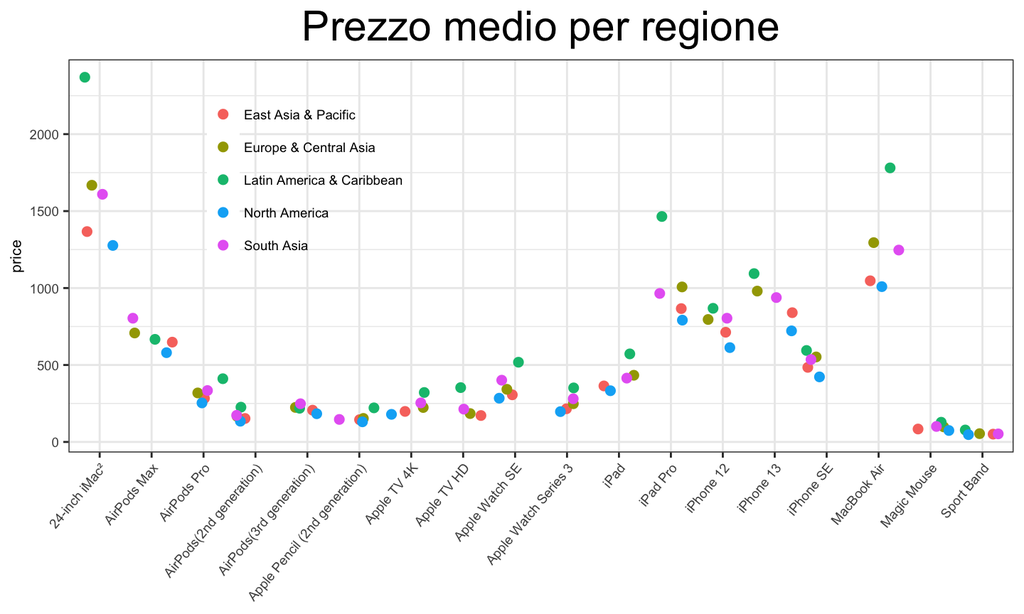

## Analisi dei prodotti per paese

Ora analizziamo i prodotti che dal grafico precedente hanno mostrato una maggiore differenza di prezzo.

Il primo prodotto analizzato è l’iPhone 12

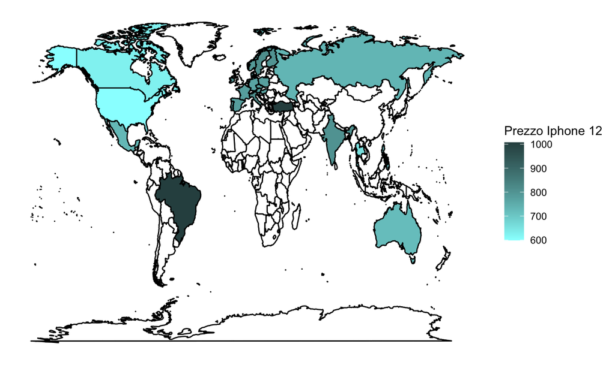

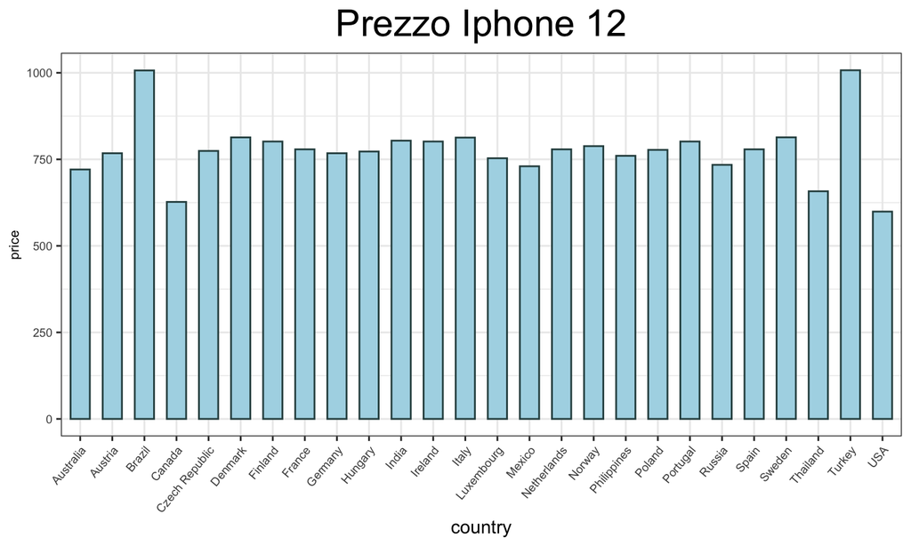

Il secondo prodotto analizzato è l’AirPods di terza generazione

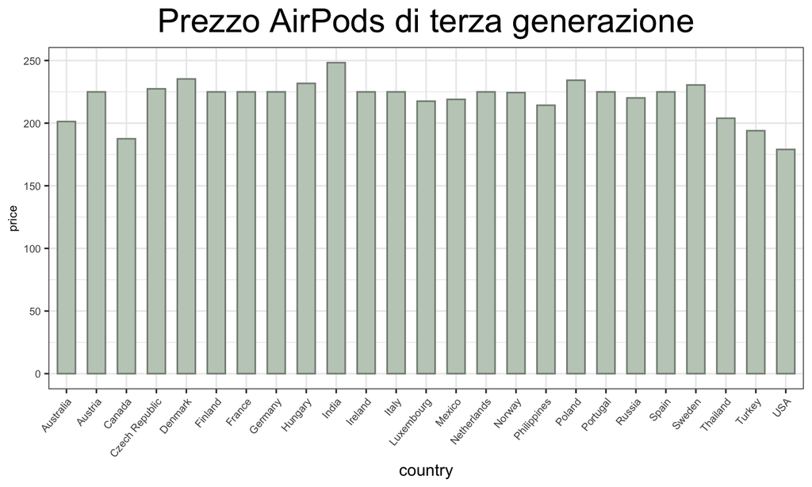

Il terzo prodotto analizzato è l’iPad Pro.

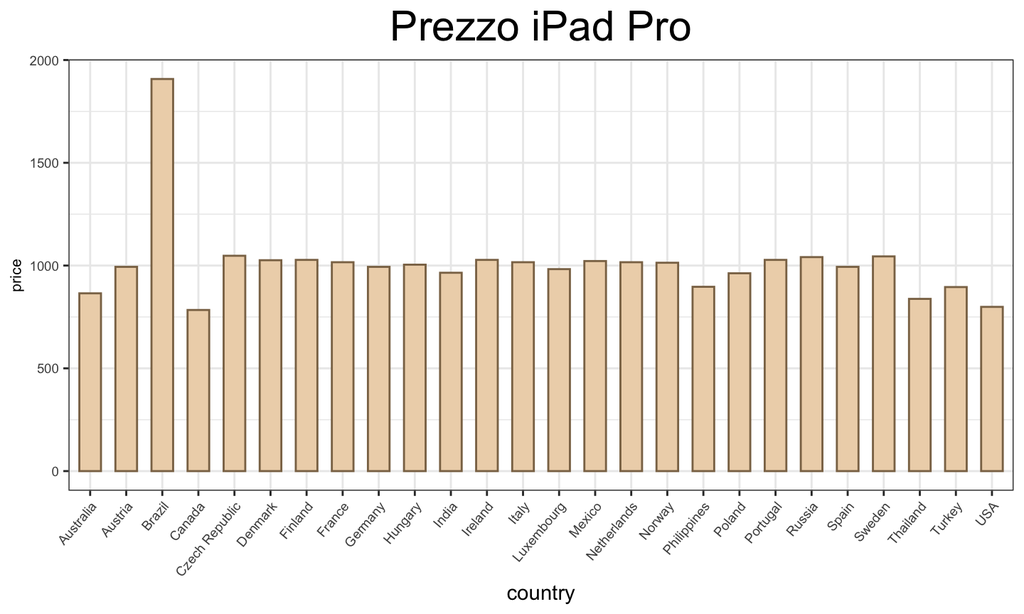

I sucessivi due prodotti analizzati sono rispettivamente il MacBook Air e il iMac 24 pollici.

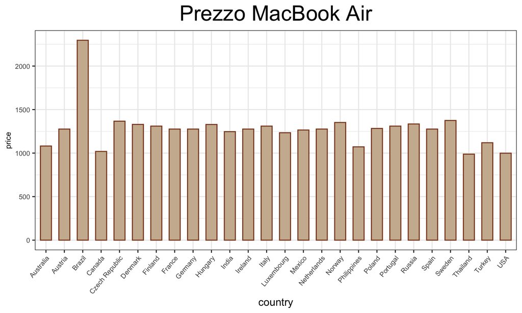

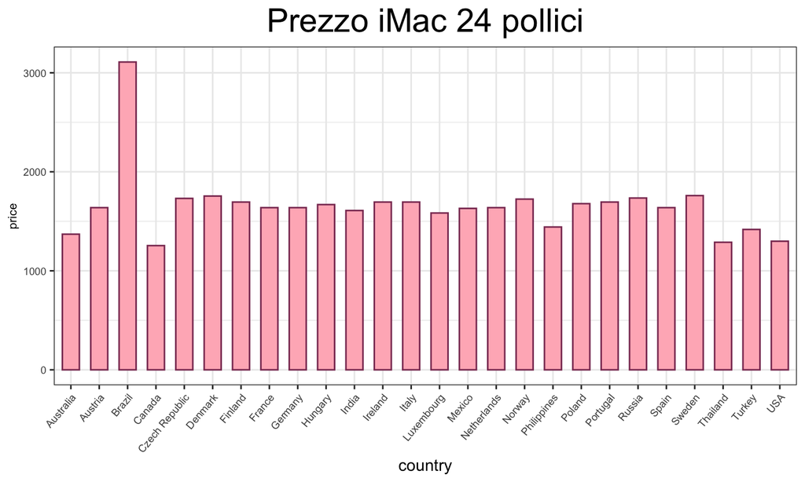

## Il prezzo più basso e più alto per ogni prodotto:

Tabella del prezzo più basso per ogni prodotto

|  | model | min_price | country |
| --- | --- | --- | --- |
| 1 | 24-inch iMac² | 1254.71794348669 | Canada |
| 2 | AirPods Max | 549 | USA |
| 3 | AirPods Pro | 249 | USA |
| 4 | AirPods(2nd generation) | 129 | USA |
| 5 | AirPods(3rd generation) | 179 | USA |
| 6 | Apple Pencil (2nd generation) | 113.358208955224 | Turkey |
| 7 | Apple TV 4K | 179 | USA |
| 8 | Apple TV HD | 168.178268965103 | Thailand |
| 9 | Apple Watch SE | 279 | USA |
| 10 | Apple Watch Series 3 | 195.387597203368 | Canada |

[output cut: 8 more lines]

Gli Stati Uniti e il Canada sono i paesi che hanno il prezzo più basso questo sopratutto perché non hanno costi di spedizione.

Tabella del prezzo più alto per ogni prodotto

|  | model | max_price | country |
| --- | --- | --- | --- |
| 1 | 24-inch iMac² | 3108.98494706476 | Brazil |
| 2 | AirPods Max | 803.940516454609 | India |
| 3 | AirPods Pro | 529.79407104081 | Brazil |
| 4 | AirPods(2nd generation) | 291.307243463253 | Brazil |
| 5 | AirPods(3rd generation) | 248.295485048585 | India |
| 6 | Apple Pencil (2nd generation) | 282.474397997417 | Brazil |
| 7 | Apple TV 4K | 423.799925450784 | Brazil |
| 8 | Apple TV HD | 353.137161724101 | Brazil |
| 9 | Apple Watch SE | 671.119598494177 | Brazil |
| 10 | Apple Watch Series 3 | 459.131307314126 | Brazil |

[output cut: 8 more lines]

## Perchè in Brasile i prodotti costano così tanto?

Dalle analisi svolte in precedenza viene spontaneo chiedersi perchè ci sia una differenza così sostanziale di prezzo dei prodotti Apple in Brasile rispetto agli altri paesi.

In Brasile e in India il governo impone tasse salatissime per i dispositivi che non vengono prodotti nel paese, ed è proprio per ottenere incentivi fiscali mirati che negli ultimi anni Apple ha iniziato ad assemblare gli iPhone in questi paesi.

I prezzi elevati sono dovuti alle misure protezionistiche che regolamentano le importazioni nel tentativo di proteggere le proprie economie. Anche la qualità delle infrastrutture non aiuta, ed elementi come i costi di consegna e trasporto, probabilmente influenzano altresì i prezzi finali.

Da una ricerca online, si è visto che in realtà il paese con un prezzo maggiore è l’Argentina dove per esempio per un iPhone 12 che in Italia costa (di listino) 839 €, in Argentina bisogna spendere 2248€.

I prodotti Apple in Argentina sono mediamente più costosi del 161,89% rispetto ad altre parti del mondo; in Brasile sono mediamente il 60,38% in più costosi.

Gli Stati Uniti sono più economici del 21% rispetto alla media.

L’Italia si trova al 22° posto in classifica nell’elenco dei paesi più costosi dove comprare un prodotto Apple.

In seguito viene riportato un istogramma con la media dei prezzi dei prodotti per ogni paese.

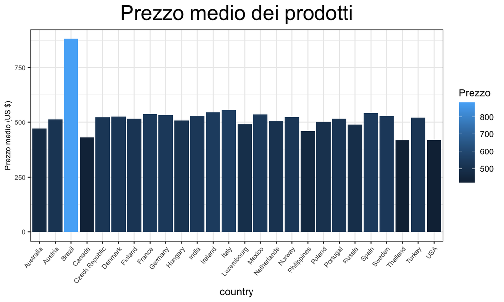

## Analisi del reddito medio di ogni paese

L’ultima analisi svolta è stata sul reddito di ogni paese. I dati analizzati sono stati presi dall’OECD, l’organizzazione per la cooperazione e lo sviluppo economico. Essi riguardavano la mediana del reddito annuo dei 26 paesi presi in esame.

Il reddito mediano è una metrica utilizzata per identificare il punto medio della distribuzione del reddito di una determinata nazione. Poiché la mediana è leggermente diversa da una media, porta ad avere meno valori “anomali” che potrebbero annullare l’accuratezza di una statistica.

Dal grafico seguente si può visualizzare il reddito mensile dei paesi.

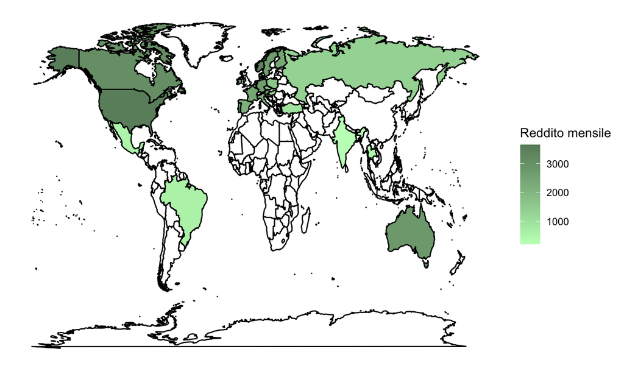

Giorni lavorativi medi necessari per l’acquisto di un iPhone 12

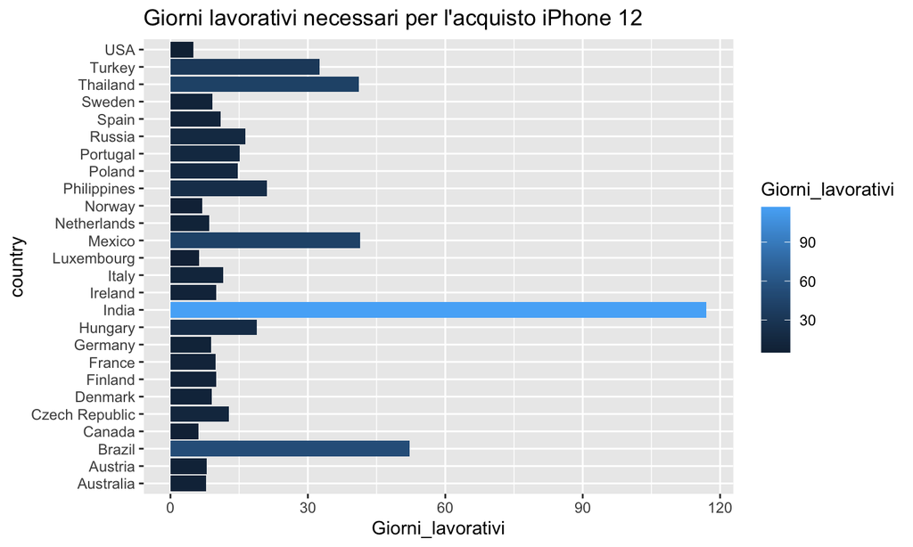

Giorni lavorativi medi necessari per l’acquisto di un iMac 24 pollici

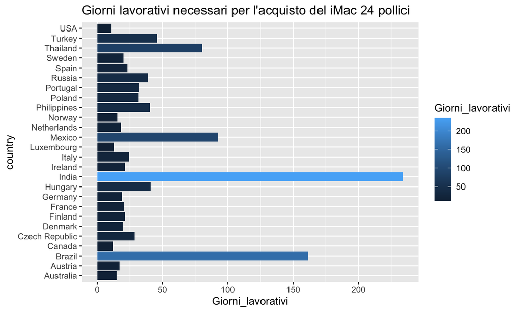